# Homework 6

## MATH 104A

### Amir Ostrowsky

#### 11-22-2019

# 1. Natural Spline $S(x)$

that interpolates $(x_j,f_j)$ with $f_j = f(x_j)$ for $j = ,0,\dots, n$ and $x_j < x_{j+1}$ for $j = 0,\dots,n-1$

$A\mathbf{x} = \mathbf{d} \textrm{ in matrix form is } \left[ {\begin{array}{*{5}c} a_1 & b_1 & 0 & \dots & 0\\ c_1 & a_2 & b_2 & \dots & 0\\ \vdots & & \ddots & & \vdots \\ 0 & \dots & c_{n-2} & a_{n-1} & b_{n-1}\\ 0 & \dots & & c_{n-1} & a_n \end{array} } \right] \begin{align} \begin{bmatrix} x_{1} \\ x_{2} \\ \vdots \\ x_{n-1} \\ x_n \end{bmatrix} &= \begin{bmatrix} d_{1} \\ d_{2} \\ \vdots \\ d_{n-1} \\ d_n \end{bmatrix} \end{align} $

with

$\begin{align} L = \left[ {\begin{array}{*{5}c} 1 & 0 & 0 & \dots & 0\\ l_1 & 1 & 0 & \dots & 0\\ \vdots & & \ddots & & \vdots \\ 0 & \dots & l_{n-2} & 1 & 0\\ 0 & \dots & & l_{n-1} & 1 \end{array} } \right] \end{align} \quad$ being a a lower triangular matrix and $\quad \begin{align} U = \left[ {\begin{array}{*{5}c} m_1 & u_1 & 0 & \dots & 0\\ 0 & m_2 & u_2 & \dots & 0\\ \vdots & & \ddots & & \vdots \\ 0 & \dots & 0 & m_{n-1} & u_{n-1}\\ 0 & \dots & & 0 & m_n \end{array} } \right] \end{align} $

being an upper triangular matrix

\left[ {\begin{array}{*{5}c} m_1 & u_1 & 0 & \dots & 0\\ 0 & m_2 & u_2 & \dots & 0\\ \vdots & & \ddots & & \vdots \\ 0 & \dots & 0 & m_{n-1} & u_{n-1}\\ 0 & \dots & & 0 & m_n \end{array} } \right] $

So the psudocode algorithm for $(x_0,\dots, x_n)$ is

**Factorization coefficients**

$m_1 = a_1$

for $j = 1:N-1$

$\quad \quad l_j = c_j/m_j$

$\quad \quad m_{j+1} = a_{j+1}-l_jb_j$

end

**Forward substitution on** $L\mathbf{y} = \mathbf{d}$

$y_1 = d_1$

for $j = 2:N$

$\quad \quad y_j = d_j-l_{j-1}y_{j-1}$

end

**Backwards substitution to solve** $U\mathbf{x} = \mathbf{y}$

$x_N = y_N/m_N$

for $j = N-1:1$

$\quad \quad x_j = (y_j-b_jx_{j+1})/m_j$

end

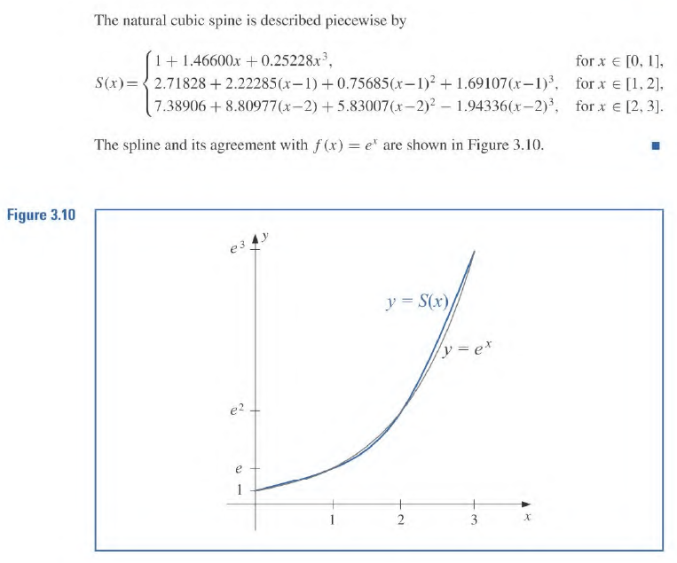

```python
'''
FUNCTION OF APPROXIMATION FOR SPLINE TESTING PURPOSES f(x)
INPUT:
real value 'x'
OUTPUT:
the exponential function of input value x

TRIDIAGONAL SQUARE MATIX SOLVER BY FACTORIZATION INTO
UPPER TRIANGULAR TIMES LOWER TRIANGULAR MATRICES LUfactorization
INPUT: tridiagonal matrix coefficients' arrays 'a', 'b', 'c', 'd'
OUTPUT: the vector Z of dimension (n-1 x 1) which are the second
derivatives of the domain nodes z_j for j = 0,...,n
from the equation Az = d


NATURAL SPLINE FUNCTION natSpline
INPUT:
'x' is a value from domain [x_0, x_n] ,
'Xnodes' is an array of n+1 nodes from the domain of function of
approximation f(x),
'Fnodes' is an array of n+1 nodes from the range of function of
approximation f(x),
'displayCoeffs' is the boolean condition of whether to output 1 value
of the spline per one value 'x' or to display the arrays of spline
coefficients A,B,C,D
OUTPUT:
if displayCoeffs is false it outputs one value of the natural spline
function per one value of 'x'
otherwise it outputs the arrays of coefficients of the spline for each
interval (x_j, x_{j+1}) for j = 0,...,n-1

VARIABLES, ARRAYS AND CONSTANTS:
'Xnodes' is an array of n+1 nodes from the domain of function of
approximation f(x),
'Fnodes' is an array of n+1 nodes from the range of function of
approximation f(x),
'n' is the number of nodes for input,
'coeffs' is an array of the arrays of coefficients of the spline,
'N' is the number intervals of the piecewise spline function,
'dtype' is an input for a display table column names and datatype of
values for each value of each column,
't_S' is the table of coefficients of the spline
'''

import numpy as np
import math
from astropy.table import Table, Column

def f(x):
    return(math.exp(x))

def LUfactorization(a,b,c,d):
    # factorization coefficients
    m = np.array([]); l = np.array([])
    m = np.append(m, a[0])
    n = int(a.size)
    for j in range(n-1):
        l = np.append(l, c[j] / m[j] )
        m = np.append(m, a[j+1]-l[j]*b[j])

    # Forward substitution on Ly = d
    y = np.array([])
    y = np.append(y, d[0])
    for j in range(1,n):
        y = np.append(y, d[j]-l[j-1]*y[j-1])

    # Backward substitution to solve Ux = y
    z = np.zeros(n)
    z[n-1] = y[n-1] / (m[n-1]+0.0)

    for j in range(n-2, -1, -1):
        z[j] = (y[j]-b[j]*z[j+1])/m[j]

    return z

def natSpline(x,Xnodes, Fnodes, displayCoeffs = 0):
    a = np.array([]); b = np.array([]); c = np.array([]); d = np.array([]); h = np.array([])
    n = int( Xnodes.size)

    for j in range(n-1):
        h = np.append(h, Xnodes[j+1]-Xnodes[j])

    for j in range(1,n-1):
        a = np.append(a, 2*(h[j]+h[j-1]))
        d = np.append(d, -6*(Fnodes[j]-Fnodes[j-1])/h[j-1] + 6*(Fnodes[j+1]-Fnodes[j])/h[j] )

    for j in range(1,n-2):
        b = np.append(b, h[j])
        c = np.append(c, h[j-1])

    z = LUfactorization(a,b,c,d) #z_j for j = 1,...,n-1
    z = np.insert(z, 0, 0, axis=0) # z_0 = 0
    z = np.append(z, 0) # z_n = 0

    A = np.array([]); B = np.array([]); C = np.array([]); D = np.array([])
    for j in range(n-1):
        A = np.append(A, (z[j+1]-z[j])/(6*h[j]) )
        B = np.append(B, 0.5*z[j] )
        C = np.append(C, (Fnodes[j+1]-Fnodes[j])/h[j] - (h[j]/6)*(z[j+1]+2*z[j]) )
        D = np.append(D, Fnodes[j] )

    if displayCoeffs == 1:
        coeffs = np.empty([n-1, 4])
        for i in range(n-1):
            coeffs[i][0] = A[i]
            coeffs[i][1] = B[i]
            coeffs[i][2] = C[i]
            coeffs[i][3] = D[i]
        return (coeffs)
    else:
        epsilon = 10**(-10)
        s = np.array([])
        for j in range(n-1):
            s = np.append(s, A[j]*(x-Xnodes[j])**3 + B[j]*(x-Xnodes[j])**2 + C[j]*(x-Xnodes[j]) + D[j])

        # x outside of domain [a = x_0, b = x_n]
        if x < Xnodes[0] or x > Xnodes[n-1]:
            return("x is out of bounds")

        # if x = x_j for j = 0,...,n
        for j in range(n):
            if abs(x-Xnodes[j]) < epsilon:
                return(Fnodes[j])

        # if x is between x_j and x_{j+1}
        for j in range(n-1):
            if x > Xnodes[j] and x < Xnodes[j+1]:
                return(s[j])


Xnodes = np.array([])
Fnodes = np.array([])

n = 3

for j in range(n+1):
    Xnodes = np.append(Xnodes, j)
    Fnodes = np.append(Fnodes, f( j ))

natSpline_of_2 = natSpline(2.0,Xnodes, Fnodes)
print('Natural spline of 2.0 %a' %natSpline_of_2)

coeffs = natSpline(0.9,Xnodes, Fnodes, 1)

N = int( Fnodes.size - 1)
dtype = [('$j$', 'i4'), ('$x_j$','f8'), ('$f_j$','f8'),
         ('$A_j$', 'f8'), ('$B_j$', 'f8'), ('$C_j$', 'f8'),
         ('$D_j$', 'f8')]
t_S = Table(data=np.zeros(N, dtype=dtype))
for j in range(len(t_S)):
    t_S[j] = (j, round(Xnodes[j],3),  round(Fnodes[j],3),
               round(coeffs[j][0],5), round(coeffs[j][1],5),
               round(coeffs[j][2],5), round(coeffs[j][3],5))
t_S
```

```
Natural spline of 2.0 7.38905609893065
```

*Table length=3*

| $j$ int32 | $x_j$ float64 | $f_j$ float64 | $A_j$ float64 | $B_j$ float64 | $C_j$ float64 | $D_j$ float64 |
| --- | --- | --- | --- | --- | --- | --- |
| 0 | 0.0 | 1.0 | 0.25228 | 0.0 | 1.466 | 1.0 |
| 1 | 1.0 | 2.718 | 1.69107 | 0.75685 | 2.22285 | 2.71828 |
| 2 | 2.0 | 7.389 | -1.94336 | 5.83007 | 8.80977 | 7.38906 |

# 2.

$$x = x(t), \quad y = y(t) \quad \textrm{ for } \quad t \in [a,b] \\ \textrm{ for two splines interpolating } (t_j, x_j) \textrm{ and } (t_j, y_j) \quad \textrm{ for } \quad j = 0,\dots, n$$$$\\t_0=0, \;t_j = t_{j+1}+\sqrt{(x_j-x_{j-1})^2+(y_j-y_{j-1})^2} \quad \textrm{ for } \quad j = 1,\dots,n$$

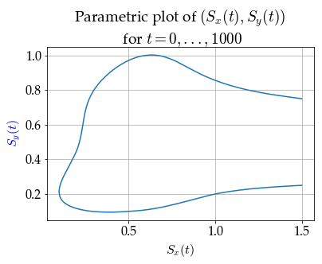

*Table length=8*

| $j$ int32 | $x_j$ float64 | $A_j$ float64 | $B_j$ float64 | $C_j$ float64 | $D_j$ float64 |
| --- | --- | --- | --- | --- | --- |
| 0 | 1.5 | 0.07016 | 0.0 | -0.99767 | 1.5 |
| 1 | 0.9 | -0.69987 | 0.13008 | -0.91728 | 0.9 |
| 2 | 0.6 | 2.6035 | -0.53549 | -1.03274 | 0.6 |
| 3 | 0.3 | -3.00065 | 1.96387 | -0.57512 | 0.3 |
| 4 | 0.2 | 6.18971 | -1.46588 | -0.42532 | 0.2 |
| 5 | 0.1 | -3.28823 | 3.52922 | 0.07499 | 0.1 |
| 6 | 0.5 | 0.43401 | -0.53503 | 1.14037 | 0.5 |
| 7 | 1.0 | -0.08549 | 0.129 | 0.95078 | 1.0 |

```python
'''
VARIABLES, ARRAYS AND CONSTANTS:
'T' is an array of the input variable for the parametric function
f(x(t), y(t)),
'n_e' is the number of values to graph (resolution),
'S_x' is the spline with domain nodes t_j and range nodes from the
domain of function of approximation f(x),
'S_y' is the spline with domain nodes t_j and range nodes from the
range of function of approximation f(x),
'S_xCoeffs' is an array of arrays of coefficients of spline S_x,
'n' is the number of piecewise function intervals of spline S_x,
't_Sx' is the table of coefficients of the spline S_x
'''

import matplotlib
# importing the graphing library
import matplotlib.pyplot as plt
from matplotlib import rc
from IPython.display import display, Math, Latex

# Say, "the default sans-serif font is Palatino Linotype"
matplotlib.rcParams['font.serif'] = "Palatino Linotype"
# Then, "ALWAYS use serif fonts"
matplotlib.rcParams['font.family'] = "serif"
# set the default Latex font for Latex text
plt.rcParams["mathtext.fontset"] = "cm"
# set default font size
matplotlib.rcParams.update({'font.size': 16})

# ==================================================================================

n_e = 1000
T = np.array([]);S_x = np.array([]); S_y = np.array([])

tNodes = np.array([0,0.618,0.935,1.255,1.636,1.905, 2.317,2.827, 3.33])
xNodes = np.array([1.5,0.9,0.6,0.3,0.2,0.1, 0.5, 1.0, 1.5])
fNodes = np.array([0.75,0.9,1.0,0.8,0.45,0.2,0.1,0.2,0.25])

# t_j for j = 0,...,8
for j in range(n_e+1):
    T = np.append(T, (tNodes[-1]*j)/n_e )

for j in range(n_e+1):
    S_x = np.append(S_x, natSpline(T[j], tNodes, xNodes) )
    S_y = np.append(S_y, natSpline(T[j], tNodes, fNodes) )

# plotting the function for approximation
plt.plot(S_x, S_y)
# displays grid, x and y axis labels and title
plt.grid(True, which='both')
plt.ylabel('$S_y(t)$', color = 'b')
plt.xlabel('$S_x(t)$')
plt.title( 'Parametric plot of $(S_x(t), S_y(t))$ \n for $t = 0,...,{}$' .format(n_e) )

# function to show the plot
plt.show()

#=======================================================================================
from astropy.table import Table, Column

S_xCoeffs = natSpline(0.9,tNodes, xNodes, 1)

n = int( fNodes.size - 1)
dtype = [('$j$', 'i4'), ('$x_j$','f8'), ('$A_j$', 'f8'),
         ('$B_j$', 'f8'), ('$C_j$', 'f8'), ('$D_j$', 'f8')]
t_Sx = Table(data=np.zeros(n, dtype=dtype))
for j in range(len(t_Sx)):
    t_Sx[j] = (j, round(xNodes[j],3),round(S_xCoeffs[j][0],5),
            round(S_xCoeffs[j][1],5), round(S_xCoeffs[j][2],5),
            round(S_xCoeffs[j][3],5))
t_Sx
```

```python
'''
VARIABLES, ARRAYS AND CONSTANTS:
'S_yCoeffs' is an array of arrays of coefficients of spline S_y,
't_Sy' is the table of coefficients of the spline S_y
'''

S_yCoeffs = natSpline(0.9,tNodes, fNodes, 1)

dtype = [('$j$', 'i4'), ('$f_j$','f8'), ('$A_j$', 'f8'),
         ('$B_j$', 'f8'), ('$C_j$', 'f8'), ('$D_j$', 'f8')]
t_Sy = Table(data=np.zeros(n, dtype=dtype))
for j in range(len(t_Sy)):
    t_Sy[j] = (j, round(fNodes[j],3),round(S_yCoeffs[j][0],5),
            round(S_yCoeffs[j][1],5), round(S_yCoeffs[j][2],5),
            round(S_yCoeffs[j][3],5))
t_Sy
```

*Table length=8*

| $j$ int32 | $f_j$ float64 | $A_j$ float64 | $B_j$ float64 | $C_j$ float64 | $D_j$ float64 |
| --- | --- | --- | --- | --- | --- |
| 0 | 0.75 | 0.28974 | 0.0 | 0.13206 | 0.75 |
| 1 | 0.9 | -3.17308 | 0.53717 | 0.46403 | 0.9 |
| 2 | 1.0 | 2.60565 | -2.48043 | -0.09808 | 1.0 |
| 3 | 0.8 | -0.30323 | 0.021 | -0.88262 | 0.8 |
| 4 | 0.45 | 2.17401 | -0.32559 | -0.9991 | 0.45 |
| 5 | 0.2 | -0.68876 | 1.42883 | -0.71448 | 0.2 |
| 6 | 0.1 | -0.54778 | 0.57752 | 0.04402 | 0.1 |
| 7 | 0.2 | 0.17269 | -0.26059 | 0.18679 | 0.2 |